# lab4

Jose Ordoñez, Adrián González, Daniela Ramirez

2026-03-20

Link de Git: https://github.com/JoseOrdonezB/Lab4-MD.git

## Librerias

```r
library(rpart)
library(rpart.plot)
library(Metrics)
library(caret)
library(randomForest)
```

## Carga de datos

```r
load("listings.RData")
head(listings)
```

```
##      id                        listing_url    scrape_id last_scraped
## 1  5456  https://www.airbnb.com/rooms/5456 2.025092e+13   2025-09-17
## 2  6448  https://www.airbnb.com/rooms/6448 2.025092e+13   2025-09-17
## 3  8502  https://www.airbnb.com/rooms/8502 2.025092e+13   2025-09-17
## 4 13035 https://www.airbnb.com/rooms/13035 2.025092e+13   2025-09-17
## 5 22828 https://www.airbnb.com/rooms/22828 2.025092e+13   2025-09-16
## 6 47572 https://www.airbnb.com/rooms/47572 2.025092e+13   2025-09-16
##        source                                               name
## 1 city scrape          Walk to 6th, Rainey St and Convention Ctr
## 2 city scrape Secluded Studio @ Zilker - King Bed, Bright & Airy
## 3 city scrape                            Woodland Studio Lodging
## 4 city scrape      Historic house in highly walkable East Austin
## 5 city scrape                 Garage Apartment central SE Austin
## 6 city scrape Cozy Private Room in North Austin for Longer Stays
##                                                                                                                                                                                                                                                                                                          …
```

[output cut: 195 more lines]

```r
str(listings)
```

```
## 'data.frame':    171748 obs. of  80 variables:
##  $ id                                          : num  5456 6448 8502 13035 22828 ...
##  $ listing_url                                 : chr  "https://www.airbnb.com/rooms/5456" "https://www.airbnb.com/rooms/6448" "https://www.airbnb.com/rooms/8502" "https://www.airbnb.com/rooms/13035" ...
##  $ scrape_id                                   : num  2.03e+13 2.03e+13 2.03e+13 2.03e+13 2.03e+13 ...
##  $ last_scraped                                : chr  "2025-09-17" "2025-09-17" "2025-09-17" "2025-09-17" ...
##  $ source                                      : chr  "city scrape" "city scrape" "city scrape" "city scrape" ...
##  $ name                                        : chr  "Walk to 6th, Rainey St and Convention Ctr" "Secluded Studio @ Zilker - King Bed, Bright & Airy" "Woodland Studio Lodging" "Historic house in highly walkable East Austin" ...
##  $ description                                 : chr  "Great central  location for walking to Convention Center, Rainey Street, East 6th Street, Downtown, Congress Av"| __truncated__ "Clean, private space with everything you need for a quiet, comfy, private stay close to Zilker Park and Barton "|…
##  $ neighborhood_overview                       : chr  "My neighborhood is ideally located if you want to walk to bars and restaurants downtown, East 6th Street or Rai"| __truncated__ "The neighborhood is fun and funky (but quiet)! People are friendly  and you can't beat the location." "" "East Ce…
##  $ picture_url                                 : chr  "https://a0.muscache.com/pictures/14084884/b5a35a84_original.jpg" "https://a0.muscache.com/pictures/airflow/Hosting-6448/original/a0ab6e9c-58ed-4d57-acb1-60cb68b068e0.jpg" "https://a0.muscache.com/pictures/miso/Hosting-8502/original/be48ea3b-6…
##  $ host_id                                     : int  8028 14156 25298 50793 56488 215917 230747 272156 268988 378744 ...
##  $ host_url                                    : chr  "https://www.airbnb.com/users/show/8028" "https://www.airbnb.com/users/show/14156" "https://www.airbnb.com/users/show/25298" "https://www.airbnb.com/users/show/50793" ...
##  $ host_name                                   : chr  "Sylvia" "Amy" "Karen" "Margaret Ann" ...
##  $ host_since                                  : chr  "2009-02-16" "2009-04-20" "2009-07-11" "2009-11-02" ...
##  $ host_location                               : chr  "Austin, TX" "Austin, TX" "Austin, TX" "Austin, TX" ...
```

[output cut: 66 more lines]

```r
summary(listings)
```

```
##        id            listing_url          scrape_id         last_scraped
##  Min.   :6.000e+00   Length:171748      Min.   :2.025e+13   Length:171748
##  1st Qu.:3.599e+07   Class :character   1st Qu.:2.025e+13   Class :character
##  Median :7.250e+17   Mode  :character   Median :2.025e+13   Mode  :character
##  Mean   :6.363e+17                      Mean   :2.025e+13
##  3rd Qu.:1.183e+18                      3rd Qu.:2.025e+13
##  Max.   :1.568e+18                      Max.   :2.025e+13
##
##     source              name           description        neighborhood_overview
##  Length:171748      Length:171748      Length:171748      Length:171748
##  Class :character   Class :character   Class :character   Class :character
##  Mode  :character   Mode  :character   Mode  :character   Mode  :character
##
##
##
##
##  picture_url           host_id            host_url          host_name
##  Length:171748      Min.   :       23   Length:171748      Length:171748
##  Class :character   1st Qu.: 26330631   Class :character   Class :character
##  Mode  :character   Median :108058504   Mode  :character   Mode  :character
##                     Mean   :200257103
##                     3rd Qu.:376574507
##                     Max.   :732092326
##
##   host_since        host_location       host_about        host_response_time
##  Length:171748      Length:171748      Length:171748      Length:171748
##  Class :character   Class :character   Class :character   Class :character
##  Mode  :character   Mode  :character   Mode  :character   Mode  :character
##
##
##
##
##  host_response_rate host_acceptance_rate host_is_superhost  host_thumbnail_url
##  Length:171748      Length:171748        Length:171748      Length:171748
##  Class :character   Class :character     Class :character   Class :character
##  Mode  :character   Mode  :character     Mode  :character   Mode  :character
##
##
##
##
```

[output cut: 153 more lines]

```
##  Min.   : 0.00000                            Min.   :  0.010
##  1st Qu.: 0.00000                            1st Qu.:  0.190
##  Median : 0.00000                            Median :  0.700
##  Mean   : 0.08211                            Mean   :  1.344
##  3rd Qu.: 0.00000                            3rd Qu.:  2.000
##  Max.   :60.00000                            Max.   :120.370
##                                              NA's   :40287
##      city
##  Length:171748
##  Class :character
##  Mode  :character
##
##
##
##
```

```r
listings$price <- as.numeric(gsub("[$,]", "", listings$price))
listings_clean <- listings
listings_clean <- listings_clean[!is.na(listings_clean$price), ]

median_cols <- c(
"bedrooms",
"beds",
"bathrooms",
"host_listings_count",
"host_total_listings_count"
)

listings_clean[median_cols] <- lapply(listings_clean[median_cols], function(x){
  x[is.na(x)] <- median(x, na.rm=TRUE)
  x
})

review_cols <- c(
"review_scores_rating",
"review_scores_accuracy",
"review_scores_cleanliness",
"review_scores_checkin",
"review_scores_communication",
"review_scores_location",
"review_scores_value",
"reviews_per_month"
)

listings_clean[review_cols] <- lapply(listings_clean[review_cols], function(x){
  x[is.na(x)] <- 0
  x
})

# eliminar filas con NA en variables clave
cols_importantes <- c(
  "price", "accommodates", "bedrooms", "bathrooms", "beds"
)

listings_clean <- listings_clean[complete.cases(listings_clean[, cols_importantes]), ]

# eliminar columnas irrelevantes o problemáticas
cols_remove <- c(
"id","listing_url","picture_url","host_url","description","host_about",
"amenities","name"
)

listings_clean <- listings_clean[, !(names(listings_clean) %in% cols_remove)]

# eliminar columnas con muchos NA (>30%)
na_threshold <- 0.3
listings_clean <- listings_clean[, colMeans(is.na(listings_clean)) < na_threshold]

# eliminar columnas de fechas (no útiles para el modelo)
cols_remove_extra <- c(
  "host_since", "first_review", "last_review", "calendar_last_scraped"
)

listings_clean <- listings_clean[, !(names(listings_clean) %in% cols_remove_extra)]

# eliminar columna con muchos NA restante
listings_clean$license <- NULL

# convertir porcentajes a numéricos
listings_clean$host_response_rate <- as.numeric(gsub("%","", listings_clean$host_response_rate))
listings_clean$host_acceptance_rate <- as.numeric(gsub("%","", listings_clean$host_acceptance_rate))
# imputar NA generados
listings_clean$host_response_rate[is.na(listings_clean$host_response_rate)] <-
  median(listings_clean$host_response_rate, na.rm=TRUE)

listings_clean$host_acceptance_rate[is.na(listings_clean$host_acceptance_rate)] <-
  median(listings_clean$host_acceptance_rate, na.rm=TRUE)


cols_remove_extra2 <- c(
  "host_name",
  "host_thumbnail_url",
  "host_picture_url",
  "neighborhood_overview"
)

listings_clean <- listings_clean[, !(names(listings_clean) %in% cols_remove_extra2)]

listings_clean$host_location <- NULL
listings_clean$host_neighbourhood <- NULL

# convertir variables categóricas a factor
listings_clean <- data.frame(lapply(listings_clean, function(x) {
  if(is.character(x)) as.factor(x) else x
}))

cols_na <- c(
  "minimum_minimum_nights",
  "maximum_minimum_nights",
  "minimum_maximum_nights",
  "maximum_maximum_nights"
)

listings_clean <- listings_clean[, !(names(listings_clean) %in% cols_na)]

colSums(is.na(listings_clean))
```

```
##                                    scrape_id
##                                            0
##                                 last_scraped
##                                            0
##                                       source
##                                            0
##                                      host_id
##                                            0
##                           host_response_time
##                                            0
##                           host_response_rate
##                                            0
##                         host_acceptance_rate
##                                            0
##                            host_is_superhost
##                                            0
##                          host_listings_count
##                                            0
##                    host_total_listings_count
##                                            0
##                           host_verifications
##                                            0
##                         host_has_profile_pic
##                                            0
##                       host_identity_verified
##                                            0
##                                neighbourhood
##                                            0
##                       neighbourhood_cleansed
##                                            0
##                                     latitude
##                                            0
##                                    longitude
##                                            0
##                                property_type
##                                            0
##                                    room_type
##                                            0
##                                 accommodates
##                                            0
```

[output cut: 55 more lines]

```
##                                            0
##                             instant_bookable
##                                            0
##               calculated_host_listings_count
##                                            0
##  calculated_host_listings_count_entire_homes
##                                            0
## calculated_host_listings_count_private_rooms
##                                            0
##  calculated_host_listings_count_shared_rooms
##                                            0
##                            reviews_per_month
##                                            0
##                                         city
##                                            0
```

```r
dim(listings_clean)
```

```
## [1] 76246    55
```

```r
str(listings_clean)
```

```
## 'data.frame':    76246 obs. of  55 variables:
##  $ scrape_id                                   : num  2.03e+13 2.03e+13 2.03e+13 2.03e+13 2.03e+13 ...
##  $ last_scraped                                : Factor w/ 7 levels "2025-09-16","2025-09-17",..: 2 2 2 2 1 1 2 2 2 1 ...
##  $ source                                      : Factor w/ 1 level "city scrape": 1 1 1 1 1 1 1 1 1 1 ...
##  $ host_id                                     : int  8028 14156 25298 50793 56488 215917 230747 272156 268988 378744 ...
##  $ host_response_time                          : Factor w/ 6 levels "","a few days or more",..: 5 6 4 6 6 3 3 6 4 6 ...
##  $ host_response_rate                          : num  100 100 100 100 100 100 100 100 100 100 ...
##  $ host_acceptance_rate                        : num  90 96 60 91 71 99 99 99 63 100 ...
##  $ host_is_superhost                           : Factor w/ 3 levels "","f","t": 3 3 2 3 3 2 2 3 2 2 ...
##  $ host_listings_count                         : int  1 1 1 2 1 1 1 1 1 1 ...
##  $ host_total_listings_count                   : int  2 2 1 2 1 1 2 2 2 1 ...
##  $ host_verifications                          : Factor w/ 8 levels "['email', 'phone', 'work_email']",..: 2 2 2 2 2 1 2 2 2 1 ...
##  $ host_has_profile_pic                        : Factor w/ 3 levels "","f","t": 3 3 3 3 3 3 3 3 3 3 ...
##  $ host_identity_verified                      : Factor w/ 3 levels "","f","t": 3 3 2 3 3 3 2 3 3 3 ...
##  $ neighbourhood                               : Factor w/ 3 levels "","Neighborhood highlights",..: 2 2 1 2 2 2 1 2 2 2 ...
```

[output cut: 41 more lines]

Durante el proceso de preprocesamiento de datos, se eliminaron ciertas variables debido a que presentaban alta cardinalidad o contenían texto libre, como nombres, descripciones y ubicaciones específicas. Estas variables generan una gran cantidad de valores únicos que dificultan el entrenamiento de los modelos y pueden provocar errores durante la predicción, además de no aportar un valor significativo en la estimación del precio. Por ello, se optó por conservar únicamente variables relevantes y estructuradas que contribuyen de manera efectiva al desempeño del modelo.

## Inciso No. 1

```r
set.seed(123)

train_index <- sample(1:nrow(listings_clean), 0.7*nrow(listings_clean))

train_data <- listings_clean[train_index, ]
test_data <- listings_clean[-train_index, ]

dim(train_data)
```

```
## [1] 53372    55
```

```r
dim(test_data)
```

```
## [1] 22874    55
```

El conjunto de entrenamiento quedó conformado por 53,372 observaciones, mientras que el conjunto de prueba contiene 22,874 observaciones. Esta división se realizó de manera aleatoria utilizando una semilla fija (set.seed(123)), lo que garantiza que los resultados sean reproducibles en futuras ejecuciones.

## Inciso No. 2

```r
tree_reg <- rpart(price ~ ., data = train_data, method = "anova")
```

Se construyó un modelo de árbol de regresión con el objetivo de predecir el precio por noche de las propiedades, utilizando todas las variables disponibles en el conjunto de entrenamiento (train_data).

Para la implementación se utilizó el algoritmo de árboles de decisión mediante la función rpart, configurando el método como “anova”.

## Inciso No. 3

```r
pred_tree <- predict(tree_reg, test_data)

rmse_tree <- rmse(test_data$price, pred_tree)
rmse_tree
```

```
## [1] 2041.26
```

Al comparar este valor con el precio promedio de las propiedades, se observa que el modelo presenta una precisión limitada, lo que sugiere que no logra capturar completamente la complejidad y variabilidad del mercado de precios.

Este comportamiento puede explicarse debido a que los árboles de regresión tienden a generar predicciones constantes dentro de cada segmento, lo que reduce su capacidad para modelar relaciones más complejas entre las variables.

Este resultado servirá como referencia para comparar el desempeño de modelos con diferentes configuraciones de profundidad del árbol en los siguientes incisos.

```r
depths <- c(3, 5, 7, 10)

rmse_results <- c()

for(d in depths){

  modelo <- rpart(price ~ .,
                  data = train_data,
                  method = "anova",
                  control = rpart.control(maxdepth = d))

  pred <- predict(modelo, test_data)

  rmse_val <- rmse(test_data$price, pred)

  rmse_results <- c(rmse_results, rmse_val)
}

data.frame(
  profundidad = depths,
  RMSE = rmse_results
)
```

```
##   profundidad     RMSE
## 1           3 2508.662
## 2           5 2233.759
## 3           7 2103.651
## 4          10 2041.260
```

Se construyeron varios modelos de árboles de regresión variando la profundidad máxima (maxdepth) con el objetivo de analizar el impacto de la complejidad del modelo en su desempeño predictivo. Se observa que, a medida que aumenta la profundidad del árbol, el valor del RMSE disminuye progresivamente. Esto indica que el modelo mejora su capacidad de predicción al incorporar mayor complejidad y capturar relaciones más detalladas entre las variables.

Sin embargo, es importante considerar que un aumento en la profundidad del árbol también incrementa el riesgo de sobreajuste (overfitting), ya que el modelo puede comenzar a adaptarse demasiado a los datos de entrenamiento y perder capacidad de generalización.

## Comparación con modelo lineal en laboratorio anterior

Se comparó el desempeño del modelo de árbol de regresión con el modelo de regresión lineal múltiple desarrollado en la entrega anterior, utilizando el RMSE como métrica de evaluación.

Este resultado sugiere que el árbol de regresión logra capturar mejor la complejidad del problema, modelando relaciones no lineales e interacciones entre variables que no son consideradas en el modelo de regresión lineal.

Por el contrario, la regresión lineal asume una relación lineal entre las variables predictoras y la variable objetivo, lo cual limita su capacidad para adaptarse a la alta variabilidad y complejidad presente en los precios de los alojamientos.

## Inciso No. 6

```r
summary(listings_clean$price)
```

```
##    Min. 1st Qu.  Median    Mean 3rd Qu.    Max.
##     8.0   120.0   193.0   750.5   326.0 50123.0
```

```r
quantile(listings_clean$price, probs = c(0.25, 0.5, 0.75))
```

```
## 25% 50% 75%
## 120 193 326
```

A partir del análisis exploratorio de la variable price, se observó que la distribución presenta una fuerte asimetría positiva, evidenciada por una media considerablemente mayor que la mediana, así como la presencia de valores extremos elevados.

Por esta razón, se decidió utilizar los cuartiles como criterio para definir los límites de las categorías, ya que estos son más robustos frente a valores atípicos.

Los puntos de corte seleccionados fueron:

**Primer cuartil (Q1)**: 120 **Tercer cuartil (Q3)**: 326

Con base en estos valores, se definieron las siguientes categorías:

**Económicas**: precios menores o iguales a 120 **Intermedias**: precios entre 120 y 326 **Caras**: precios mayores a 326

```r
listings_clean$price_category <- cut(
  listings_clean$price,
  breaks = c(-Inf, 120, 326, Inf),
  labels = c("Economica", "Intermedia", "Cara")
)

table(listings_clean$price_category)
```

```
##
##  Economica Intermedia       Cara
##      19310      37882      19054
```

```r
prop.table(table(listings_clean$price_category))
```

```
##
##  Economica Intermedia       Cara
##  0.2532592  0.4968392  0.2499016
```

Luego de definir la variable categórica, se analizó la distribución de las clases obtenidas. Se observa que la categoría Intermedia concentra aproximadamente el 49.68% de las observaciones, mientras que las categorías Económica y Cara representan el 25.33% y 24.99% respectivamente.

Esta distribución indica que las clases están relativamente balanceadas, lo cual es favorable para el entrenamiento de modelos de clasificación, ya que evita sesgos hacia una categoría dominante y permite que el modelo aprenda patrones representativos de cada grupo de precios.

## Inciso No. 7

Para evitar fuga de información (data leakage), se eliminó la variable price del conjunto de entrenamiento, ya que fue utilizada para construir la variable respuesta.

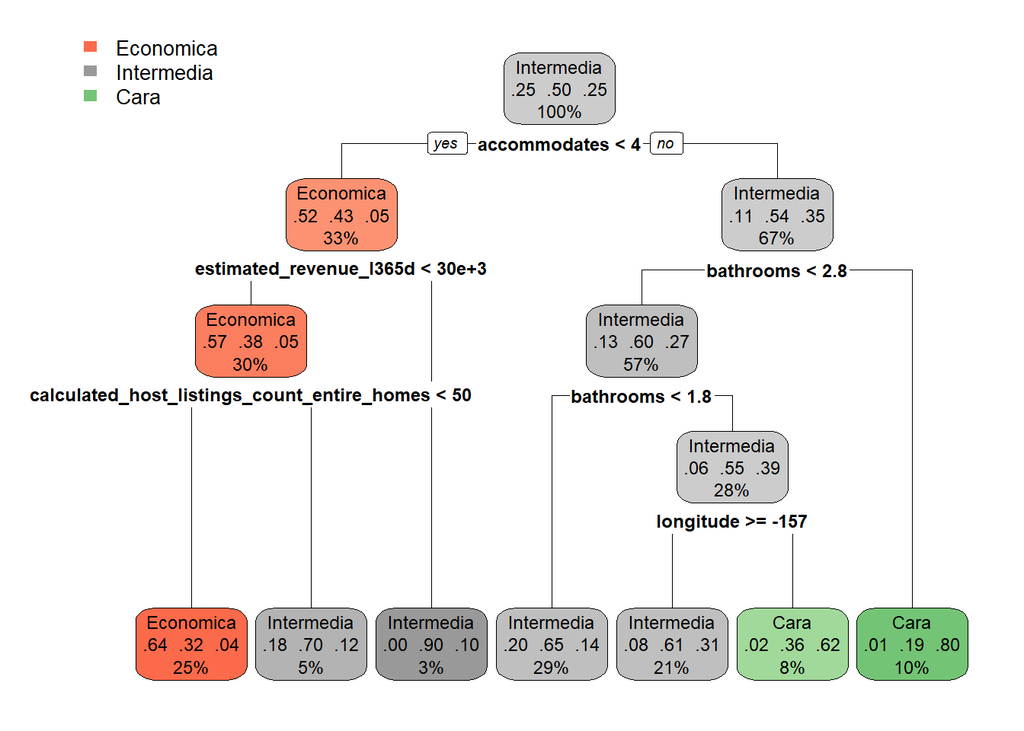

```r
# 1. Crear variable respuesta
listings_clean$price_category <- cut(
  listings_clean$price,
  breaks = c(-Inf, 120, 326, Inf),
  labels = c("Economica", "Intermedia", "Cara")
)

# 2. Split de datos
set.seed(123)
train_index <- sample(1:nrow(listings_clean), 0.7*nrow(listings_clean))

train_data <- listings_clean[train_index, ]
test_data <- listings_clean[-train_index, ]

# 3. Preparar datos
train_class <- train_data
test_class <- test_data

# eliminar price
train_class$price <- NULL
test_class$price <- NULL

# 4. Seleccionar solo variables numéricas
train_class_num <- train_class[, sapply(train_class, is.numeric)]

# agregar variable respuesta nuevamente
train_class_num$price_category <- train_class$price_category

# 5. Reducir tamaño del dataset (eficiencia)
set.seed(123)
train_sample <- train_class_num[sample(1:nrow(train_class_num), 10000), ]

# 6. Entrenar modelo
tree_class <- rpart(
  price_category ~ .,
  data = train_sample,
  method = "class",
  control = rpart.control(
    maxdepth = 4,
    minsplit = 200,
    cp = 0.01
  )
)

# 7. Mostrar árbol
rpart.plot(tree_class, type = 2, extra = 104)
```

El árbol de clasificación muestra que la variable más importante para clasificar el precio de las propiedades es accommodates, ya que aparece en el nodo raíz del modelo.

Esto indica que la capacidad de alojamiento es el factor principal que determina si una propiedad es económica, intermedia o cara. En particular, se observa que las propiedades con capacidad menor a 4 personas tienden a clasificarse principalmente como económicas.

En los niveles siguientes del árbol, aparecen variables como estimated_revenue_l365d y calculated_host_listings_count_entire_homes, las cuales permiten refinar la clasificación dentro del grupo de propiedades económicas e intermedias. Estas variables están relacionadas con el desempeño y la escala de operación del anfitrión.

Para propiedades con mayor capacidad, la variable bathrooms juega un papel importante, indicando que el número de baños influye significativamente en la diferenciación entre propiedades intermedias y caras.

Finalmente, variables como longitude permiten una segmentación adicional, sugiriendo que la ubicación geográfica también tiene impacto en la clasificación del precio.

```r
# predicciones en test
pred_class <- predict(tree_class, test_class, type = "class")

head(data.frame(
  Real = test_class$price_category,
  Predicho = pred_class
))
```

```
##          Real  Predicho
## 1   Economica Economica
## 4  Intermedia Economica
## 13  Economica Economica
## 14  Economica Economica
## 19  Economica Economica
## 25  Economica Economica
```

```r
accuracy <- mean(pred_class == test_class$price_category)
accuracy
```

```
## [1] 0.6665209
```

El modelo de árbol de clasificación fue aplicado al conjunto de prueba con el objetivo de evaluar su capacidad para clasificar correctamente los alojamientos en las categorías Económica, Intermedia y Cara.

Para medir la eficiencia del modelo se utilizó la métrica de exactitud (accuracy), obteniendo un valor de 0.6665. Esto indica que el modelo clasifica correctamente la mayor parte de los alojamientos en el conjunto de prueba.

Esto sugiere que el modelo tiene una capacidad moderada de clasificación, logrando identificar correctamente cerca de dos tercios de los casos. Considerando que el problema involucra tres categorías y que la variable precio presenta alta variabilidad, este nivel de desempeño parece razonable. Además, dado que las clases se encuentran relativamente balanceadas, el valor de accuracy es representativo del desempeño general del modelo y no está sesgado hacia una categoría dominante.

```r
conf_matrix <- table(
  Real = test_class$price_category,
  Predicho = pred_class
)

conf_matrix
```

```
##             Predicho
## Real         Economica Intermedia Cara
##   Economica       3796       1942   63
##   Intermedia      1741       8629 1100
##   Cara             234       2548 2821
```

```r
# Proporción (porcentaje)
prop.table(conf_matrix)
```

```
##             Predicho
## Real           Economica  Intermedia        Cara
##   Economica  0.165952610 0.084899886 0.002754219
##   Intermedia 0.076112617 0.377240535 0.048089534
##   Cara       0.010229955 0.111392848 0.123327796
```

El modelo presenta un desempeño adecuado, logrando clasificar correctamente una proporción considerable de los alojamientos. Se observa que la categoría Intermedia es la que presenta mayor número de aciertos, lo cual es consistente con el hecho de que esta es la clase más frecuente en el conjunto de datos. Asimismo, la categoría Económica también muestra un buen nivel de clasificación correcta, lo que indica que el modelo logra identificar patrones claros en los alojamientos de menor precio.

Sin embargo, el modelo presenta mayores dificultades al momento de diferenciar entre categorías cercanas. En particular, se observa que un número significativo de alojamientos que pertenecen a la categoría Intermedia son clasificados como Económicos, lo que indica una tendencia a subestimar algunos precios. De forma similar, muchos alojamientos que son realmente Caros son clasificados como Intermedios, lo que sugiere que el modelo tiene limitaciones para distinguir correctamente en los rangos superiores de precio.

Por otro lado, es importante destacar que los errores entre categorías extremas son relativamente pocos. Es decir, el modelo rara vez clasifica un alojamiento económico como caro o viceversa. Este comportamiento es positivo, ya que indica que el modelo logra capturar correctamente las diferencias más marcadas entre los niveles de precio, evitando errores más graves desde una perspectiva práctica.

Desde el punto de vista del negocio, los errores más frecuentes, que ocurren entre categorías adyacentes, pueden ser considerados menos críticos. Sin embargo, estos errores aún pueden tener impacto, ya que una clasificación incorrecta podría influir en la estimación del valor de una propiedad o en la estrategia de recomendación. A pesar de ello, el hecho de que los errores más extremos sean poco comunes sugiere que el modelo mantiene un nivel aceptable de confiabilidad.

## Inciso No. 10

```r
control <- trainControl(method = "cv", number = 10)

set.seed(123)
tree_cv <- train(
  price_category ~ .,
  data = train_class_num,
  method = "rpart",
  trControl = control,
  tuneLength = 5
)

tree_cv
```

```
## CART
##
## 53372 samples
##    39 predictor
##     3 classes: 'Economica', 'Intermedia', 'Cara'
##
## No pre-processing
## Resampling: Cross-Validated (10 fold)
## Summary of sample sizes: 48034, 48035, 48034, 48035, 48035, 48034, ...
## Resampling results across tuning parameters:
##
##   cp          Accuracy   Kappa
##   0.01185089  0.6791951  0.4784079
##   0.01845326  0.6544062  0.4229031
##   0.04172849  0.6367764  0.3881956
##   0.05063056  0.6118191  0.3571665
##   0.10157641  0.5444034  0.1663607
##
## Accuracy was used to select the optimal model using the largest value.
## The final value used for the model was cp = 0.01185089.
```

El modelo anterior obtuvo una precisión de 66.65%, mientras que el modelo entrenado con validación cruzada alcanzó una precisión de 67.92%.

Esto representa una mejora aproximada del 1.27%, lo que indica un ligero incremento en el desempeño del modelo.

Aunque la mejora en precisión no es considerablemente alta, el uso de validación cruzada permite obtener un modelo más robusto y confiable, ya que evalúa su desempeño en múltiples particiones de los datos, reduciendo el riesgo de sobreajuste.

## Inciso No. 11

```r
depths <- c(2, 4, 6, 8)

results <- data.frame()

for(d in depths){

  modelo <- rpart(
    price_category ~ .,
    data = train_class_num,
    method = "class",
    control = rpart.control(maxdepth = d)
  )

  test_class_num <- test_class[, sapply(test_class, is.numeric)]

  pred <- predict(modelo, test_class_num, type = "class")

  acc <- mean(pred == test_class$price_category)

  results <- rbind(results, data.frame(
    profundidad = d,
    accuracy = acc
  ))
}

results
```

```
##   profundidad  accuracy
## 1           2 0.6316342
## 2           4 0.6677013
## 3           6 0.6896476
## 4           8 0.6896476
```

Se evaluaron distintos modelos de árboles de clasificación variando la profundidad máxima del árbol.

Los resultados obtenidos muestran que la precisión del modelo aumenta conforme se incrementa la profundidad, pasando de 63.16% con profundidad 2, a un máximo de 68.96% con profundidad 6.

Sin embargo, al aumentar la profundidad a 8, no se observa una mejora adicional en la precisión, manteniéndose en 68.96%.

Esto indica que el modelo alcanza su mejor desempeño con una profundidad de 6, logrando un equilibrio adecuado entre complejidad y capacidad predictiva.

## Inciso No. 12

```r
#Evitar data leakage
train_data$price_category <- NULL
test_data$price_category <- NULL
```

```r
# eliminar alta cardinalidad en train y test
high_cardinality <- sapply(train_data, function(x){
  is.factor(x) && length(unique(x)) > 50
})

train_data <- train_data[, !high_cardinality]
test_data  <- test_data[, !high_cardinality]
```

```r
# modelo random forest
# Tarda en correr (tener paciencia)
set.seed(123)

rf_reg <- randomForest(
  price ~ .,
  data = train_data,
  ntree = 100,
  mtry = floor(sqrt(ncol(train_data)-1)),
  importance = TRUE
)
```

```r
# predicción
pred_rf <- predict(rf_reg, test_data)

rmse_rf <- rmse(test_data$price, pred_rf)
rmse_rf
```

```
## [1] 1337.628
```

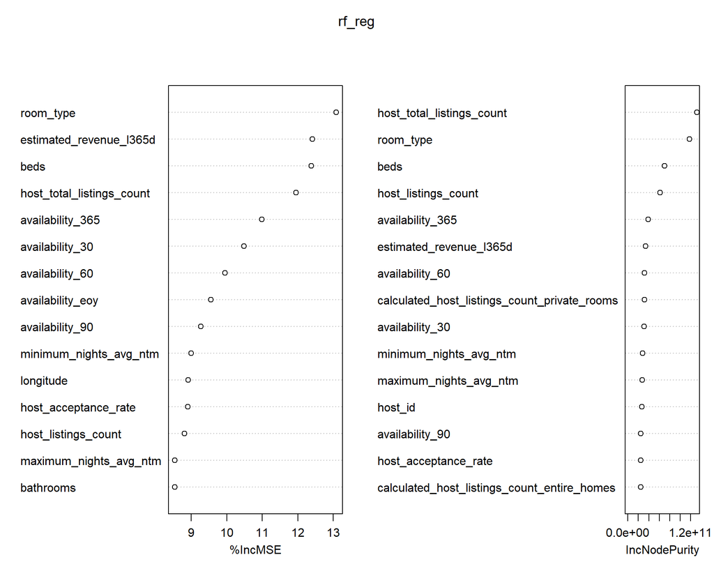

```r
varImpPlot(rf_reg, n.var = 15)
```

El análisis de importancia de variables muestra que factores como el tipo de habitación (room_type), los ingresos estimados del alojamiento (estimated_revenue_l365d), el número de camas (beds), la cantidad de propiedades del anfitrión (host_total_listings_count) y la disponibilidad anual (availability_365) tienen una influencia significativa en la predicción del precio.

Estos resultados son consistentes con la lógica del mercado, ya que reflejan tanto características físicas del alojamiento como variables relacionadas con la demanda y el desempeño del anfitrión.

En comparación con el árbol de regresión, el modelo de Random Forest logra capturar relaciones más complejas y no lineales entre las variables, reduciendo el error de predicción y mejorando la capacidad de generalización